# **Devoir Maison**

## Schéma de géotraitement de la fusion

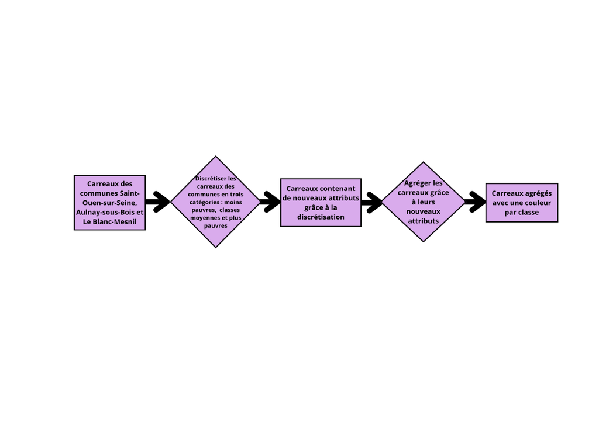

```r
# Code pour afficher l'image
library(imager)
mon_image <- load.image("C:/Users/Tia/Downloads/fusion_géotraitement.png")
plot(mon_image, axes = FALSE)
```

# **GT Rasters**

Mais avant de poursuivre notre analyse, la déontologie nous oblige à préciser que nos traitements, et par là même notre analyse, s’est heurté à la contrainte majeure du secret statistique. En effet, étant donnée que l’Insee applique des règles strictes de confidentialité pour protéger la vie privée des ménages dans les zones peu peuplées, notre analyse n’aurait aucun sens sans les prendre en compte, de ce fait nous nous proposons d’interpréter cette absence. A cette égard, les carreaux manquants sont révélateurs, d’une part, d’une occupation non résidentielle du sol.

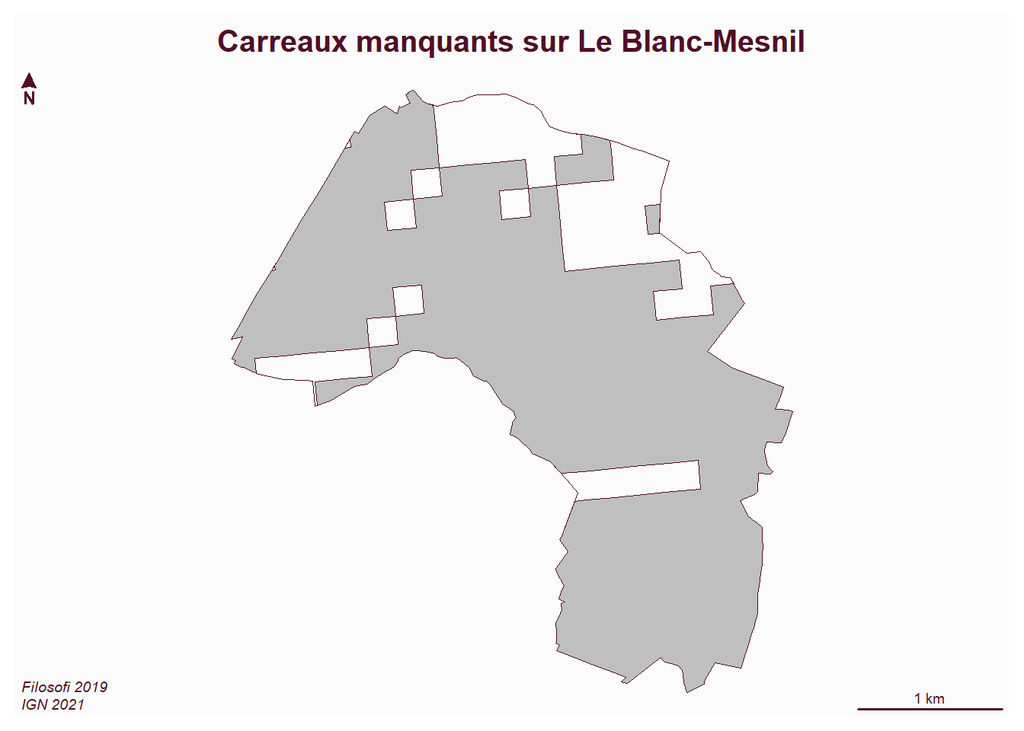

```r
library(sf)
commune <- st_read("base.gpkg", "commune", quiet=T)
blanc_mesnil <- commune [commune$code == '93007',]
st_layers("base.gpkg", "carreau_manquant")
car <- st_read("base.gpkg", "carreau_manquant", quiet=T)
inter <- st_union(st_intersection(blanc_mesnil,car))
diff <- st_difference(blanc_mesnil$geom, inter)
library(mapsf)
mf_map(diff)
mf_map(blanc_mesnil, add = T, col = NA)
mf_layout("Carreaux manquants sur Le Blanc-Mesnil","Filosofi 2019\nIGN 2021")
```

Le Blanc-Mesnil présente une distribution plus mitée des carreaux manquants, reflet d’un tissu pavillonnaire parfois lâche ou de zones d’activités commerciales dispersées. Ainsi, Ces “zones blanches” masquent néanmoins une pauvreté invisible, celle des populations isolées ou vivant dans des zones d’habitat précaire illicite qui ne franchissent pas les seuils de la statistique officielle.

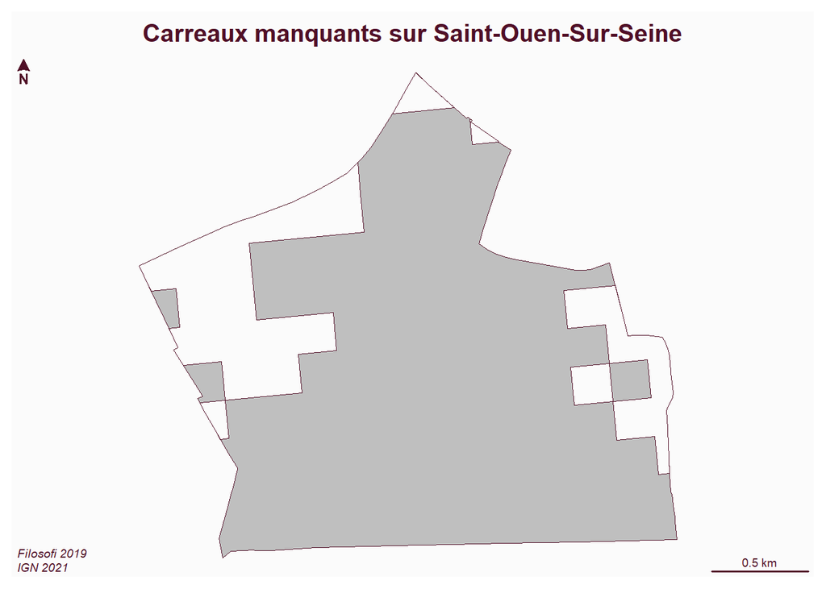

```r
library(sf)
commune <- st_read("base.gpkg", "commune", quiet=T)
saint_Ouen <- commune [commune$code == '93070',]
st_layers("base.gpkg", "carreau_manquant")
car <- st_read("base.gpkg", "carreau_manquant", quiet=T)
inter <- st_union(st_intersection(saint_Ouen,car))
diff <- st_difference(saint_Ouen$geom, inter)
library(mapsf)
mf_map(diff)
mf_map(saint_Ouen, add = T, col = NA)
mf_layout("Carreaux manquants sur Saint-Ouen-Sur-Seine","Filosofi 2019\nIGN 2021")
```

À Saint-Ouen, les vides statistiques se concentrent sur les zones d’activités industrielles, les infrastructures ferroviaires et les emprises logistiques en bord de Seine, où la population résidente est inférieure au seuil de 11 ménages requis par l’Insee

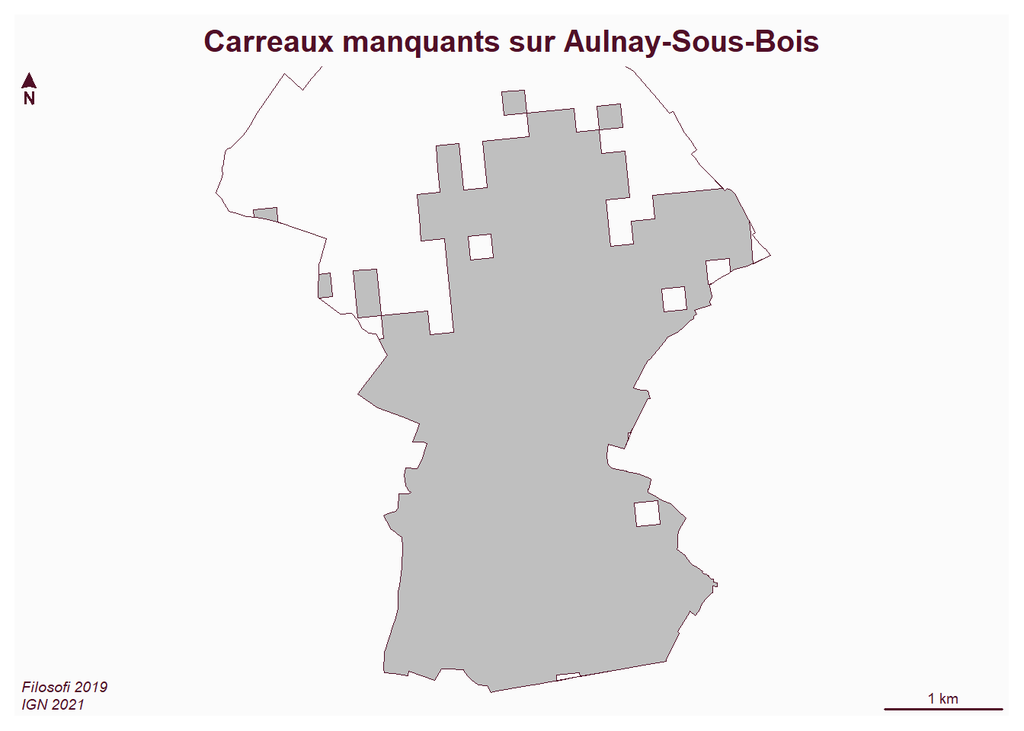

```r
#Aulnay-Sous-Bois
library(sf)
commune <- st_read("base.gpkg", "commune", quiet=T)
aulnay <- commune [commune$code == '93005',]
st_layers("base.gpkg", "carreau_manquant")
car <- st_read("base.gpkg", "carreau_manquant", quiet=T)
inter <- st_union(st_intersection(aulnay,car))
diff <- st_difference(aulnay$geom, inter)
library(mapsf)
mf_map(diff)
mf_map(aulnay, add = T, col = NA)
mf_layout("Carreaux manquants sur Aulnay-Sous-Bois","Filosofi 2019\nIGN 2021")
```

D’au part, il ne faut pas oublier que pour certains carreaux, l’Insee procède à une imputation lorsque les données sont estimées à partir du voisinage. Cette technique permet de lisser la carte mais peut introduire un biais dans l’analyse de corrélation. À Le Blanc-Mesnil, où le tissu pavillonnaire est prédominant, le risque d’imputation est plus élevé, ce qui peut atténuer artificiellement les pics de pauvreté locaux. À l’inverse, à Aulnay, la densité est telle que le secret statistique est rarement invoqué dans les zones d’habitation, garantissant une fiabilité maximale des indicateurs de précarité.

## Schéma de géotraitement des carreaux manquants

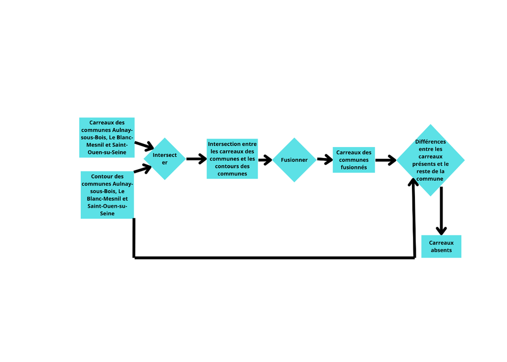

```r
# Code pour afficher l'image
library(imager)
mon_image <- load.image("C:/Users/Tia/Downloads/raster_geotraitement.png")
plot(mon_image, axes = FALSE)
```

```r
# --- DANS UN BLOC AVANT LE BLOC 9 ---
charger_fichiers <- function(nom_du_dossier) {
  library(terra)
  fichiers <- list.files(nom_du_dossier, pattern = "\\.tif$", full.names = TRUE)

  if (length(fichiers) == 0) {
    stop(paste("Erreur : Le dossier", nom_du_dossier, "est introuvable ou vide."))
  }

  if (length(fichiers) > 1) {
    return(merge(sprc(fichiers)))
  } else {
    return(rast(fichiers))
  }
}
```